# R語言資料分析競賽-分析結果

第23組

2022-05-14

# Q1：以台灣及芬蘭示範，計算兩國自評同事相處的平均數、標準差，並分別以表、圖呈現

## 資料處理

```r
### 資料準備 ################################################################################

# 匯入資料
library(haven)
issp <- read_dta("C:/Users/uio28/OneDrive/桌面/R競賽範例/2015data/2015data/ZA6770_v2-1-0.dta")

# 建立欄位敘述表
library(labelled)
issp_col <- var_label(issp)
issp_col <- unlist(issp_col)
issp_col <- data.frame(issp_col = issp_col)


###Q1：以台灣及芬蘭示範，計算兩國自評同事相處的平均數、標準差，並分別以表、圖呈現####
##國家代碼欄位：c_alphan
##自評同事相處是問項Q23：與同事間關係好壞，對應欄位是v44

#資料前處理
library(dplyr)

#選取需要的欄位形成子資料集
df <- issp %>%
  select(c_alphan, v44)

#檢視資料：國家
table(df$c_alphan)
df <- df %>%
  filter(c_alphan=='TW' | c_alphan=='FI' ) #篩選TW和FI
table(df$v44)
df <- df %>%
  filter(v44!=0 & v44!=8 & v44!=9) #刪除遺漏值代碼8 9 0(查看ZA6770_v2-1-0_missing.txt)

# 將工作滿意度的數值大小反轉
df$REL <- 8 - df$v44 # 創造變數:數值越高，工作滿意度越好
table(df$REL) # 檢查

# 完成資料前處理 檢視兩國資料
table(df$c_alphan, df$REL)

## 做表
tbl <- df %>%
  group_by(country = c_alphan) %>%          # 順便改欄位名稱
  summarise(mean = mean(REL), sd = sd(REL))

library(knitr)      # 使用knitr套件，在RMarkdown中呈現表格
library(kableExtra) # 使用kableExtra套件做較整齊的表
# 設定小數位顯示數及表標題
ktbl <- tbl %>%
  kable(digits = 2, caption = '台灣與芬蘭兩國各自的工作滿意度平均數與標準差') %>%  # 置中:align = 'c'
  kable_classic()
# 呼叫表
ktbl


## 做圖
# 可用前面做好的tbl畫圖
library(ggplot2)
breaks <- 0:10 # 設定y軸級距

# 建立圖型物件
p <- ggplot(data = tbl, mapping = aes(x = country, y = mean)) +
  geom_col(width = 0.5, fill = 'dodgerblue', color = 'black') +         # 以長條圖呈現
  geom_errorbar(aes(ymin = mean - sd, ymax = mean + sd), width = 0.3) + # 加入error_bar呈現標準差
  scale_y_continuous(breaks = breaks, limits = c(0,7)) +
  theme_bw() +
  labs(title = '工作滿意度平均數與標準差')
```

## 表

```r
# 呼叫表
ktbl
```

台灣與芬蘭兩國各自的工作滿意度平均數與標準差

| country | mean | sd |
| --- | --- | --- |
| FI | 5.45 | 1.05 |
| TW | 5.24 | 1.02 |

## 圖

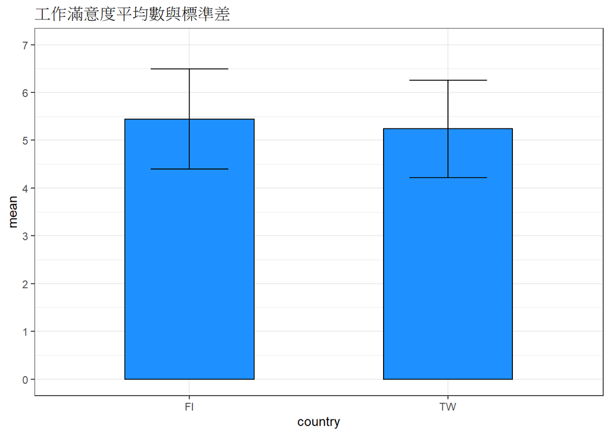

```r
# 呼叫圖
p
```

## 結論

1.根據分析結果，芬蘭工作滿意度的平均值大於台灣。

# Q2：檢定上述兩國的平均工作滿意度是否不同

## 資料處理

```r
###Q2：檢定上述兩國的平均工作滿意度是否不同####
# 找出兩國的自評同事相處向量 之後投入檢定函數中
x <- df$REL[df$c_alphan=='TW']
y <- df$REL[df$c_alphan=='FI']

# 變異數同質性檢定: 先檢定兩者變異數是否相等 再決定t-test的參數
var.test(x, y, alternative = "two.sided") # H0:var1/var2 = 1

# p>0.05 不拒絕H0，兩者變異數沒有顯著差異
```

[output not shown]

## 檢定結果

```r
# t檢定
t.test(x, y, alternative = "two.sided", var.equal = T)
```

```
##
##  Two Sample t-test
##
## data:  x and y
## t = -4.1131, df = 1935, p-value = 4.068e-05
## alternative hypothesis: true difference in means is not equal to 0
## 95 percent confidence interval:
##  -0.3023897 -0.1071251
## sample estimates:
## mean of x mean of y
##  5.240555  5.445312
```

# Q3：做表及做圖呈現男女不同年齡層分別的工作滿意度平均數及標準差

## 資料處理

```r
###Q3：做表及做圖呈現男女不同年齡層分別的工作滿意度平均數及標準差####
## 資料前處理
# 增加選取性別、年齡進入子資料集，並重複與Q1同樣的資料處理
df <- issp %>%
  select(c_alphan, v44, SEX, AGE) %>%
  filter(c_alphan=='TW' | c_alphan=='FI') %>%  # 篩選TW及FI
  filter(v44!=0 & v44!=8 & v44!=9) %>%         # 刪除遺漏值
  mutate(REL = 8 - v44)                        # 創造變數

# 檢視資料:性別
table(df$SEX) # 1是male 2是female (codebook.pdf p.228)

# 創造變數: 將性別代碼換成名稱
df$SEX <- ifelse(df$SEX==1, 'male', 'female')
df$SEX <- factor(df$SEX, levels = c('male','female')) # 調整類別變數順序

# 檢視資料:年齡
summary(df$AGE) # 統計分布 -> 出現異常值(999，查看ZA6770_v2-1-0_missing.txt)
df <- df[df$AGE!=999,] # 刪除異常值

# 創造變數: 依年齡數值切分群組 (注意DK(丹麥)的年齡欄位為DK_AGE)
breaks <- c(0, 25, 35, 45, 55, 65, Inf)                                  # 設定斷點
labels <- c('24-','25-34','35-44','45-54','55-64','65+')                 # 設定各組名稱
df$AGE_GROUP <- cut(df$AGE, breaks = breaks, labels = labels, right = F) # 不包含右端點
head(df) # 檢查一下

## 資料前處理完成，接著製作交叉統計表
# 1.台灣
temp <- df[df$c_alphan=='TW',]
y <- temp$REL        # 目標值
x1 <- temp$AGE_GROUP # 列變數
x2 <- temp$SEX       # 欄變數
mean_tw <- tapply(X = y, INDEX = list(x1, x2),FUN = mean) # 矩陣:平均數
sd_tw <- tapply(X = y, INDEX = list(x1, x2),FUN = sd)     # 矩陣:標準差

# 2.芬蘭
temp <- df[df$c_alphan=='FI',]
y <- temp$REL        # 目標值
x1 <- temp$AGE_GROUP # 列變數
x2 <- temp$SEX       # 欄變數
mean_fi <- tapply(X = y, INDEX = list(x1, x2),FUN = mean) # 矩陣:平均數
sd_fi <- tapply(X = y, INDEX = list(x1, x2),FUN = sd)     # 矩陣:標準差

# 將4個矩陣水平合併
tbl <- cbind(mean_tw, sd_tw, mean_fi, sd_fi)

# 以kableExtra套件製作有巢狀表頭的表
ktbl <- tbl %>%
  kable(caption = '台灣與芬蘭工作滿意度的平均數與標準差', digits = 2) %>%     # 設定表標題及小數位數
  kable_classic() %>%                                                           # 以較整齊的樣式呈現
  add_header_above(c(' ' = 1, 'mean' = 2, 'sd' = 2, 'mean' = 2, 'sd' = 2)) %>%  # 第二層表標題:統計量
  add_header_above(c(' ' = 1, 'TW' = 4, 'FI' = 4))                              # 第一層表標題:國家

# 呼叫表
ktbl

## 做圖
# 製作繪圖用的資料集
tbl <- df %>%
  group_by(c_alphan, SEX, AGE_GROUP) %>%
  summarise(mean = mean(REL), sd = sd(REL))

# 以長條圖呈現
p <- ggplot(data = tbl, mapping = aes(x = AGE_GROUP, y = mean, fill = SEX)) +
  geom_col(position = position_dodge()) +                                     # 設定將性別長條並排顯示
  facet_wrap(~c_alphan) +                                                     # 以分面顯示兩國
  scale_fill_manual(values = c('male' = 'skyblue', 'female' = 'tomato')) +    # 設定性別對應的顏色
  geom_errorbar(mapping = aes(ymin = mean - sd, ymax = mean + sd),
                position = position_dodge(1), width = 0.5, alpha = 0.5) +     # 以error_bar呈現標準差
  labs(title = '台灣與芬蘭工作滿意度的平均數與標準差')
```

## 表

```r
# 呼叫表
ktbl
```

台灣與芬蘭工作滿意度的平均數與標準差

|  | TW mean male | TW mean female | TW sd male | TW sd female | FI mean male | FI mean female | FI sd male | FI sd female |
| --- | --- | --- | --- | --- | --- | --- | --- | --- |
| 24- | 4.92 | 4.88 | 1.38 | 1.07 | 6.15 | 5.29 | 0.90 | 0.96 |
| 25-34 | 5.07 | 5.14 | 1.08 | 0.90 | 5.21 | 5.44 | 1.12 | 1.05 |
| 35-44 | 5.21 | 5.32 | 0.94 | 0.86 | 5.30 | 5.33 | 1.20 | 0.84 |
| 45-54 | 5.17 | 5.34 | 1.11 | 0.88 | 5.35 | 5.46 | 1.20 | 1.07 |
| 55-64 | 5.56 | 5.43 | 0.96 | 0.92 | 5.48 | 5.57 | 0.96 | 0.92 |
| 65+ | 5.65 | 5.60 | 1.14 | 0.75 | 6.33 | 6.22 | 0.72 | 0.67 |

## 圖

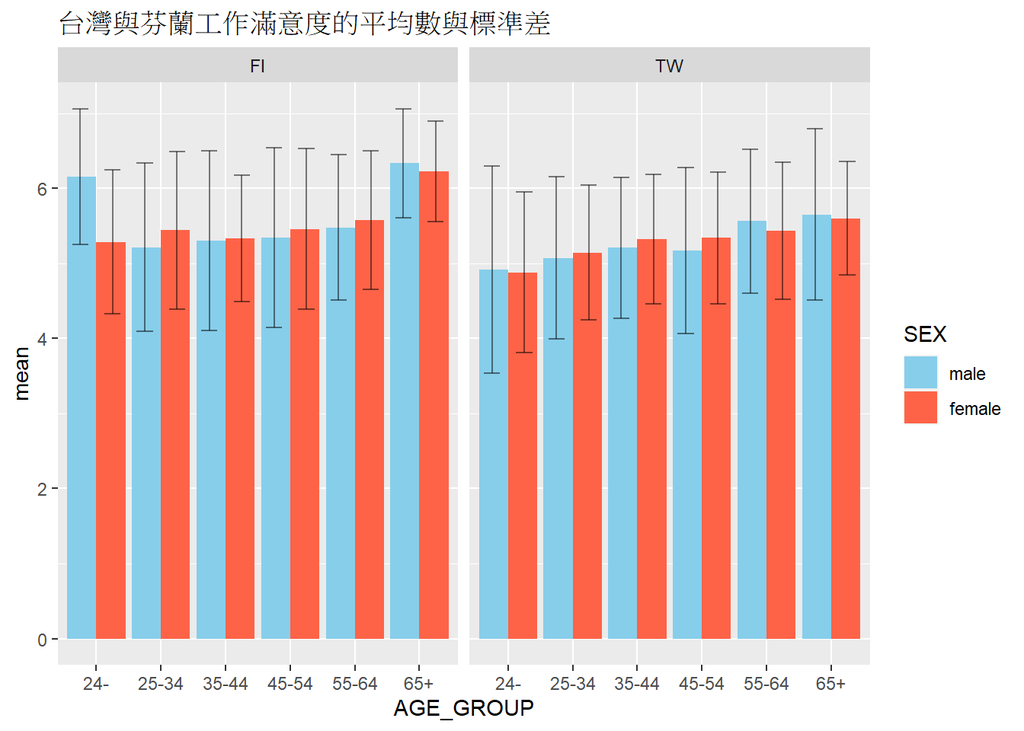

```r
# 呼叫圖
p
```

## 結論

- 就分析而言，男性除了年齡55~64之外，芬蘭的平均工作滿意度皆大於台灣，芬蘭的女性平均工作滿意度皆大於台灣。